# Londonmap_Zurichmap

GIS Part 1 Assignment – Mapping and Cartography: Critical Evaluation of Maps Produced Using Different Software Packages.

Map produces with QGIS.

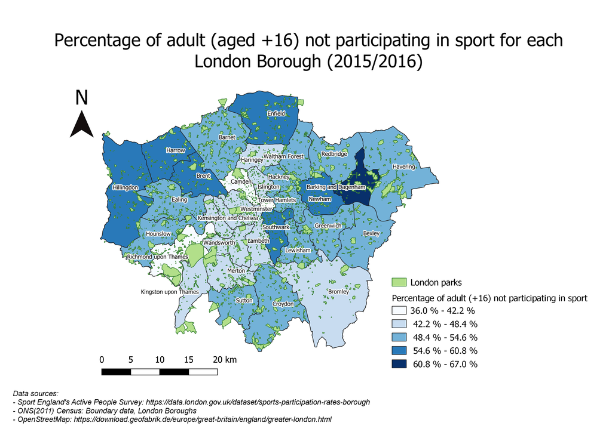

```r
knitr::include_graphics("Sport participation in London.png")
```

Map produce with R.

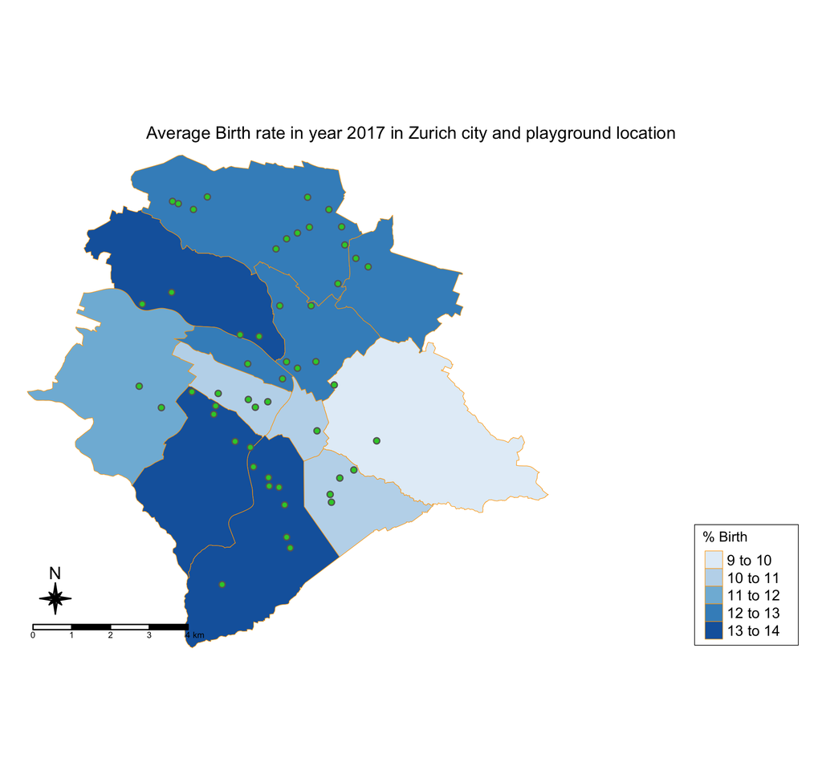

```r
knitr::include_graphics("Zurichmap.png")
```

Critical review on the work flow.

The first decision to take before starting to make a map is to choose the software to work with. QGIS is a graphical user interface (GUI), which means that a map will be created by using graphical icons. On the contrary, R is a command line interface, meaning that some knowledge in programming language is necessary to start to manipulate the data. Both software allows to import text data and geographical data.

However, I found easier to use QGIS to layout a map, and to use R to analyze the data. Once, familiar with QGIS, it was easy to add new layers, change their color and create a print version of the map on QGIS, as I could simply click on the tools proposed by the interface. R was in contrary easy to use to manipulate the datasets, to join values of text file to object of a shape file, to remove and change values in datasets or to view their properties. Both softwares have the advantage to be used by many other people and therefore have many online documents to find answer to problems.

The second step in the process of mapping is to find and download the data that will be used to create a map. Generally, I found it easy to download and access spatial data such as city boundaries or land use cover by using OpenStreetMap or ONS for London, OpenData for Z?rich. On the contrary, demographic data were more difficult to handle. Compare to the great amount of available date for London, the data for Z?rich were less detailed and less organized. In both cases, it is necessary to spend some time to arrange the data before being able to use them.

If I now analyze the two maps following the following the checklist of Krygier and Wood, I can first argue that the statistical data of the two maps are exact as they come from reliable sources (Sport England and Zurich OpenData). Moreover, it is useful to use a map to illustrate demographic trend in specific areas. However, it is legitimate to ask whether the park layer add value to the maps, and if the way they are represented is effective. In the London map, the surface or each park is shown but this does not make the definition of ?parks? clearer. One could decide to show only the parks with sport facilities to see if there would be a relation between parks and sport participation. In the Zurich map, the parks with a playground were selected from all other parks, to see if any relation between the number of playgrounds and the percentage of birth exist. Another important point is the accuracy of the coordinate reference system. London (EPSG: 4326) and Zurich (EPSG:2056) have different one and if no attention is pay to it, the overlay the layers could represent wrong spatial configuration. An advantage of the R software is the possibility to create interactive map. This gives the ability to view the map in a broader geography and with different backgrounds (topographic, openstreet) but also to navigate on the map and directly get information about what is shown.

I think that the potential of R and the various library provide by the software open some interesting possibility to analyze data and spatially represent them, if more time is spent to learn the programming language. QGIS on the contrary allows great possibility for laying the maps.